# EPI-Clone Figure 5

2025-03-06

This RMarkdown document generates Figure 5. The analysis encompasses the visualization of clonal lineage biases in the TBM and the CD34+ compartment, transcription differences between clones within the HSC/MPP compartment and, the direct comparison between EPI-clone and mitochondrial lineage tracing.

## Lineage biases expanded vs non expanded clones TBM (Fig 5A, EV8F)

Visualizing the log2 fold changes of cell type proportions in expanded clones compared to non-expanded clones elucidates lineage-specific biases associated with clonal expansions.

```r
S_tbm <- readRDS(url("https://figshare.com/ndownloader/files/51354143"))

patient.age_tbm <- S_tbm@meta.data %>%
  distinct(sample, age) %>%
  arrange(age)
patients <- patient.age_tbm$sample

#EpiClone must be executed to identify clones in each donor.
#However, to optimize computational efficiency, we are utilizing the clonal information already stored in the Seurat metadata.
#For a detailed guide on running EpiClone and generating this object, please refer to the script provided for Figure 4.
epiclones_tbm <- SplitObject(S_tbm, split.by = "sample")
epiclones_tbm <- epiclones_tbm[patients]
names(epiclones_tbm) <- patients

epiclones_tbm <- lapply(epiclones_tbm, function(x) {
  new_epi <- ifelse(
    grepl("non_expanded", x@meta.data$EPIclone_id),
    1,
    as.numeric(sub(".*_(\\d+)", "\\1", x@meta.data$EPIclone_id))
  )

  x <- AddMetaData(x, metadata = new_epi, col.name = "EPIclone_id")
})
```

```r
epiclone_vs_celltype <- lapply(patients, function(n) {
  epiclones_tbm[[n]]$simplecelltype <- epiclones_tbm[[n]]$celltype
  out <- table(epiclones_tbm[[n]]$EPIclone_id, epiclones_tbm[[n]]$celltype)
  out <- out[, colnames(out) != "Unclear", drop = FALSE]
  out <- out[, colnames(out) != "pDC", drop = FALSE]
  rownames(out) <- paste(n, rownames(out), sep = "_")
  out
})

forplot <- bind_rows(lapply(epiclones_tbm, function(x) {
  na.omit(data.frame(
    mut = x$mutation,
    CHOIR = x$EPIclone_id,
    celltype = x$celltype,
    patient = unique(x$sample)
  ))
}))

patient_totals <- forplot %>%
  group_by(patient) %>%
  dplyr::summarise(total_patient_size = n(), .groups = "drop")

forplot <- forplot %>%
  mutate(mut = if_else(mut == "N/A", NA_character_, mut)) %>%
  group_by(patient, CHOIR) %>%
  dplyr::summarise(
    size = n(),
    perc.wt = mean(mut == "wt", na.rm = TRUE),
    dominant = names(which.max(table(mut))),
    .groups = "drop"
  ) %>%
  left_join(patient_totals, by = "patient") %>%
  mutate(perc = size / total_patient_size)

forplot$key <- with(forplot, paste(patient, CHOIR, sep = "_"))
cluster2dominant <- forplot$dominant
names(cluster2dominant) <- forplot$key
cluster2size <- forplot$size
names(cluster2size) <- forplot$key
cluster2perc <- forplot$perc
names(cluster2perc) <- forplot$key

epiclone_vs_celltype <- do.call(rbind, epiclone_vs_celltype)
epiclone_vs_celltype <- epiclone_vs_celltype / rowSums(epiclone_vs_celltype)
epiclone_vs_celltype_anno <- data.frame(
  row.names = rownames(epiclone_vs_celltype),
  patient = gsub("_.+", "", rownames(epiclone_vs_celltype)),
  dominant = cluster2dominant[rownames(epiclone_vs_celltype)],
  size = cluster2size[rownames(epiclone_vs_celltype)],
  perc = cluster2perc[rownames(epiclone_vs_celltype)]
)

plf <- data.frame(epiclone_vs_celltype_anno, epiclone_vs_celltype, clone = gsub(".+_", "", rownames(epiclone_vs_celltype_anno)))
plf$dominant_plot <- factor(ifelse(plf$clone == "1", "non-expanded", ifelse(plf$dominant == "wt", "other expanded", plf$dominant)),
  levels = c(names(mutcolors), "other expanded", "non-expanded")
)
plf <- plf[order(plf$dominant_plot, decreasing = T), ]
plf$patient <- factor(plf$patient, levels = patients)
plf$expansion <- factor(ifelse(plf$clone == "1", "non-expanded", "expanded"), levels = c("non-expanded", "expanded"))
plf$is.mutation <- factor(ifelse(plf$dominant == "wt", FALSE, TRUE))
```

```r
celltypes <- c("CD34.", "Erythroid", "Immature.B", "Monocyte", "NK.cells")

non_expanded_means <- plf %>%
  filter(expansion == "non-expanded") %>%
  group_by(patient) %>%
  dplyr::summarise(across(all_of(celltypes), ~ unique(.x), .names = "non_expanded_{col}"))

clone_fold_changes <- plf %>%
  dplyr::left_join(non_expanded_means, by = "patient") %>%
  dplyr::mutate(across(all_of(celltypes),
    ~ .x / get(paste0("non_expanded_", cur_column())),
    .names = "fold_change_{col}"
  )) %>%
  dplyr::mutate(across(starts_with("fold_change_"),
    ~ log2(.x),
    .names = "log_{col}"
  )) %>%
  filter(clone != 1)

log_fold_columns <- names(clone_fold_changes)[starts_with("log_fold_change_", vars = names(clone_fold_changes))]

for (col in log_fold_columns) {
  clone_fold_changes[[col]][is.infinite(clone_fold_changes[[col]])] <-
    min(clone_fold_changes[[col]][is.finite(clone_fold_changes[[col]])], na.rm = TRUE) - 1
}
```

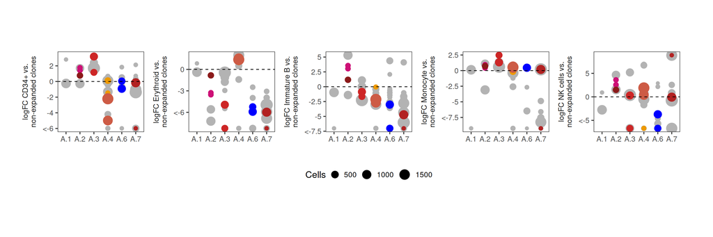

```r
clone_fold_changes_long <- clone_fold_changes %>%
  pivot_longer(
    cols = starts_with("log_fold_change_"),
    names_to = "celltype",
    values_to = "log_fold_change",
    names_prefix = "log_fold_change_"
  )

custom_y_labels <- c(
  "logFC CD34+ vs.\nnon-expanded clones",
  "logFC Erythroid vs.\nnon-expanded clones",
  "logFC Immature B vs.\nnon-expanded clones",
  "logFC Monocyte vs.\nnon-expanded clones",
  "logFC NK cells vs.\nnon-expanded clones"
)
names(custom_y_labels) <- celltypes

clone_fold_changes_long <- clone_fold_changes_long %>%
  mutate(y_label = custom_y_labels[celltype])

p <- ggplot(
  clone_fold_changes_long,
  aes(x = patient, y = log_fold_change, size = size, color = dominant)
) +
  geom_point() +
  facet_wrap(~celltype, scales = "free_y", nrow = 1, strip.position = "left", labeller = as_labeller(custom_y_labels)) +
  scale_y_continuous(
    oob = scales::squish,
    breaks = scales::breaks_extended(),
    labels = function(x) {
      x <- as.character(x)
      x[which.min(as.numeric(x))] <- paste0("<", x[which.min(as.numeric(x))])
      x
    }
  ) +
  scale_size_continuous(
    breaks = c(500, 1000, 1500),
    labels = c("500", "1000", "1500"),
    range = c(2, 8),
    name = "Cells"
  ) +
  scale_color_manual(
    name = "CHIP Clone",
    values = mutcolors,
    guide = "none"
  ) +
  xlab("") +
  ylab("") +
  theme_bw(base_size = 14) +
  theme(
    panel.grid = element_blank(),
    legend.position = "bottom",
    legend.key.width = unit(0.3, "cm"),
    legend.spacing.x = unit(0.02, "cm"),
    plot.margin = margin(t = 10, r = 50, b = 10, l = 10),
    aspect.ratio = 14 / 15,
    strip.background = element_blank(),
    strip.placement = "outside"
  ) +
  geom_hline(yintercept = 0, linetype = "dashed")

print(p)
```

```r
plf_tbm <- plf
```

## Lineage biases expanded vs non expanded clones CD34 (EV8G)

To understand how specific mutations influence hematopoietic differentiation, we compared the distribution of different cell types within expanded (mutant) and non-expanded (wild-type) clones. This analysis reveals lineage-specific biases associated with clonal expansions.

```r
S_cd34 <- readRDS(url("https://figshare.com/ndownloader/files/51354197"))

# we are only looking at patient data if there are more than 1000 cells
patient.age <- S_cd34@meta.data %>%
  distinct(sample, age) %>%
  filter(sample %in% names(table(S_cd34$sample)[table(S_cd34$sample) > 1000])) %>%
  arrange(age)

patients <- patient.age %>% pull(sample)

# EpiClone must be executed to identify clones in each donor.
# However, to optimize computational efficiency, we are utilizing the clonal information already stored in the Seurat metadata.
# For a detailed guide on running EpiClone and generating this object, please refer to the script provided for Figure 4.
epiclones_cd34 <- SplitObject(S_cd34, split.by = "sample")
epiclones_cd34 <- epiclones_cd34[patients]
names(epiclones_cd34) <- patients

epiclones_cd34 <- lapply(epiclones_cd34, function(x) {
  new_epi <- ifelse(
    grepl("non_expanded", x@meta.data$EPIclone_id),
    1,
    as.numeric(sub(".*_(\\d+)", "\\1", x@meta.data$EPIclone_id))
  )

  x <- AddMetaData(x, metadata = new_epi, col.name = "EPIclone_id")
})
```

```r
# The following Seurat object contains scTAMARA-seq data from donor X.1.
# It has been integrated with the other EpiClone Seurat objects for joint analysis.
SDR <- readRDS(url("https://figshare.com/ndownloader/files/52946162"))

# EpiClone must be executed to identify clones in each donor.
# However, to optimize computational efficiency, we are utilizing the clonal information already stored in the Seurat metadata.
epiclones_SDR <- subset(SDR, cells = names(na.omit(SDR$EPIclone_id)))
epiclones_SDR$celltype <- epiclones_SDR$projected.cluster
epiclones_cd34 <- append(epiclones_cd34, epiclones_SDR, after = 3)
names(epiclones_cd34)[[4]] <- "X.1"
patients <- names(epiclones_cd34)
```

```r
forplot <- bind_rows(lapply(epiclones_cd34, function(x) {
  x <- subset(x, cells = names(na.omit(x$EPIclone_id)))
  na.omit(data.frame(
    mut = x$mutation,
    CHOIR = as.character(x$EPIclone_id),
    celltype = x$celltype,
    patient = unique(x$sample)
  ))
}))

patient_totals <- forplot %>%
  group_by(patient) %>%
  dplyr::summarise(total_patient_size = n(), .groups = "drop")

forplot <- forplot %>%
  mutate(mut = if_else(mut == "N/A", NA_character_, mut)) %>%
  group_by(patient, CHOIR) %>%
  dplyr::summarise(
    size = n(),
    perc.wt = mean(mut == "wt", na.rm = TRUE),
    dominant = if (any(!is.na(mut))) names(which.max(table(mut))) else "wt",
    .groups = "drop"
  ) %>%
  left_join(patient_totals, by = "patient") %>%
  mutate(perc = size / total_patient_size)

forplot$key <- with(forplot, paste(patient, CHOIR, sep = "_"))
cluster2dominant <- forplot$dominant
names(cluster2dominant) <- forplot$key
cluster2size <- forplot$size
names(cluster2size) <- forplot$key
cluster2perc <- forplot$perc
names(cluster2perc) <- forplot$key

epiclone_vs_celltype <- lapply(patients, function(n) {
  epiclones_cd34[[n]]$simplecelltype <- epiclones_cd34[[n]]$celltype
  out <- table(epiclones_cd34[[n]]$EPIclone_id, epiclones_cd34[[n]]$celltype)
  rownames(out) <- paste(n, rownames(out), sep = "_")
  out
})

epiclone_vs_celltype <- do.call(rbind, epiclone_vs_celltype)
epiclone_vs_celltype <- epiclone_vs_celltype / rowSums(epiclone_vs_celltype)
epiclone_vs_celltype_anno <- data.frame(
  row.names = rownames(epiclone_vs_celltype),
  patient = gsub("_.+", "", rownames(epiclone_vs_celltype)),
  dominant = cluster2dominant[rownames(epiclone_vs_celltype)],
  size = cluster2size[rownames(epiclone_vs_celltype)],
  perc = cluster2perc[rownames(epiclone_vs_celltype)]
)

plf <- data.frame(epiclone_vs_celltype_anno, epiclone_vs_celltype, clone = gsub(".+_", "", rownames(epiclone_vs_celltype_anno)))
plf$dominant_plot <- factor(ifelse(plf$clone == "1", "non-expanded", ifelse(plf$dominant == "wt", "other expanded", plf$dominant)),
  levels = c(names(mutcolors), "other expanded", "non-expanded")
)
plf <- plf[order(plf$dominant_plot, decreasing = T), ]
plf$patient <- factor(plf$patient, levels = patients)
plf$expansion <- factor(ifelse(plf$clone == "1", "non-expanded", "expanded"), levels = c("non-expanded", "expanded"))
plf$is.mutation <- factor(ifelse(plf$dominant == "wt", FALSE, TRUE))
```

```r
celltypes <- unique(S_cd34$celltype)

non_expanded_means <- plf %>%
  filter(expansion == "non-expanded") %>%
  group_by(patient) %>%
  dplyr::summarise(across(all_of(celltypes), ~ unique(.x), .names = "non_expanded_{col}"))

clone_fold_changes <- plf %>%
  dplyr::left_join(non_expanded_means, by = "patient") %>%
  dplyr::mutate(across(all_of(celltypes),
    ~ .x / get(paste0("non_expanded_", cur_column())),
    .names = "fold_change_{col}"
  )) %>%
  dplyr::mutate(across(starts_with("fold_change_"),
    ~ log2(.x),
    .names = "log_{col}"
  )) %>%
  filter(clone != 1)

log_fold_columns <- names(clone_fold_changes)[starts_with("log_fold_change_", vars = names(clone_fold_changes))]

for (col in log_fold_columns) {
  clone_fold_changes[[col]][is.infinite(clone_fold_changes[[col]])] <-
    min(clone_fold_changes[[col]][is.finite(clone_fold_changes[[col]])], na.rm = TRUE) - 1
}
```

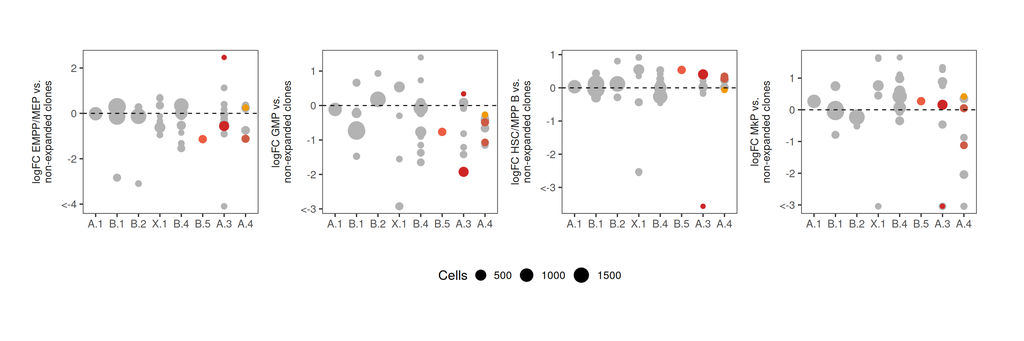

```r
clone_fold_changes_long <- clone_fold_changes %>%
  pivot_longer(
    cols = starts_with("log_fold_change_"),
    names_to = "celltype",
    values_to = "log_fold_change",
    names_prefix = "log_fold_change_"
  )

custom_y_labels <- c(
  "logFC EMPP/MEP vs.\nnon-expanded clones",
  "logFC GMP vs.\nnon-expanded clones",
  "logFC HSC/MPP B vs.\nnon-expanded clones",
  "logFC MkP vs.\nnon-expanded clones"
)

names(custom_y_labels) <- celltypes

clone_fold_changes_long <- clone_fold_changes_long %>%
  mutate(y_label = custom_y_labels[celltype])

p <- ggplot(
  clone_fold_changes_long,
  aes(x = patient, y = log_fold_change, size = size, color = dominant)
) +
  geom_point() +
  facet_wrap(~celltype, scales = "free_y", nrow = 1, strip.position = "left", labeller = as_labeller(custom_y_labels)) +
  scale_y_continuous(
    oob = scales::squish,
    breaks = scales::breaks_extended(),
    labels = function(x) {
      x <- as.character(x)
      x[which.min(as.numeric(x))] <- paste0("<", x[which.min(as.numeric(x))])
      x
    }
  ) +
  scale_size_continuous(
    breaks = c(500, 1000, 1500),
    labels = c("500", "1000", "1500"),
    range = c(2, 8),
    name = "Cells"
  ) +
  scale_color_manual(
    name = "CHIP Clone",
    values = mutcolors,
    guide = "none"
  ) +
  xlab("") +
  ylab("") +
  theme_bw(base_size = 14) +
  theme(
    panel.grid = element_blank(),
    legend.position = "bottom",
    legend.key.width = unit(0.3, "cm"),
    legend.spacing.x = unit(0.02, "cm"),
    plot.margin = margin(t = 10, r = 50, b = 10, l = 10),
    aspect.ratio = 14 / 15,
    strip.background = element_blank(),
    strip.placement = "outside"
  ) +
  geom_hline(yintercept = 0, linetype = "dashed")

print(p)
```

```r
plf_cd34 <- plf
```

## Overview lineage biases TBM and CD34+ (5B)

In this section, we present an overview of the lineage biases observed in the TMB and CD34+ compartments. Our analysis compares expanded versus non-expanded clones, as well as clones with and without clonal hematopoiesis mutations, providing insights into the underlying clonal dynamics.

```r
celltypes_tbm <- c("CD34.", "Erythroid", "Immature.B", "Monocyte", "NK.cells")
celltypes_cd34 <- unique(S_cd34$celltype)

predictors <- list(
  list(name = "expansion", coef = "expansionexpanded", comparison = "expanded vs. non-expanded"),
  list(name = "is.mutation", coef = "is.mutationTRUE", comparison = "CH vs. non-CH")
)

datasets <- list(
  tbm = list(data = plf_tbm, celltypes = celltypes_tbm),
  cd34 = list(data = plf_cd34, celltypes = celltypes_cd34)
)


results_df <- data.frame(
  Compartment = character(),
  CellType = character(),
  pvalue = numeric(),
  Comparison = character(),
  effect = integer(),
  stringsAsFactors = FALSE
)

for (compartment in names(datasets)) {
  ds <- datasets[[compartment]]
  data <- ds$data
  celltypes <- ds$celltypes
  weights_var <- data$size

  for (pred in predictors) {
    for (celltype in celltypes) {
      res <- run_model(
        data = data,
        celltype = celltype,
        predictor = pred$name,
        coef_name = pred$coef,
        comparison = pred$comparison,
        compartment = compartment,
        weight_var = weights_var
      )
      results_df <- rbind(results_df, res)
    }
  }
}
```

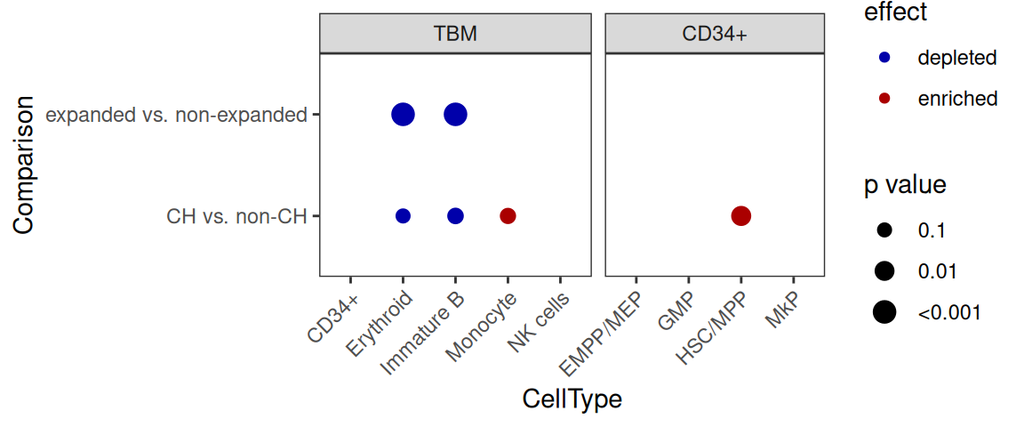

```r
results_df$squished <- with(results_df, ifelse(-log10(pvalue) > 3, 3, -log10(pvalue)))
results_df$Compartment <- factor(results_df$Compartment, levels = c("tbm", "cd34"))
results_df$CellType[results_df$CellType == "CD34."] <- "CD34+"
results_df$CellType[results_df$CellType == "Immature.B"] <- "Immature B"
results_df$CellType[results_df$CellType == "NK.cells"] <- "NK cells"
results_df$CellType[results_df$CellType == "EMPP.MEP"] <- "EMPP/MEP"
results_df$CellType[results_df$CellType == "HSC.MPP"] <- "HSC/MPP"
ggplot(aes(x = CellType, y = Comparison, color = as.character(effect), size = squished), data = results_df) +
  geom_blank() +
  facet_grid(~Compartment,
    labeller = as_labeller(c("tbm" = "TBM", "cd34" = "CD34+")),
    space = "free_x",
    scales = "free_x"
  ) +
  geom_point(data = subset(results_df, pvalue <= 0.1)) +
  scale_color_manual(name = "effect", values = c("1" = "#AA0000", "-1" = "#0000AA", "0" = "white"), labels = c("1" = "enriched", "-1" = "depleted")) +
  scale_size_continuous(name = "p value", range = c(0.1, 4), breaks = c(1, 2, 3), labels = c("0.1", "0.01", "<0.001")) +
  scale_alpha_continuous(name = "-log10 p", breaks = c(1, 2, 3), labels = c("0.1", "0.01", "<0.001")) +
  theme_bw() +
  theme(panel.grid = element_blank(), axis.text.x = element_text(angle = 45, hjust = 1))
```

## Transcriptional differences between clones within the HSC/MPP compartment (5D)

To resolve transcriptional differences between clones within the HSC/MPP compartment, we integrated targeted RNA-seq into the scTAM-seq protocol (scTAMARA-seq) by combining SDR-seq for Mission Bio Tapestri with scTAMseq. We profiled a CD34+ bone marrow sample from donor X.1, confirming the DNA methylation-based cell state annotations. This integrated approach allowed us to investigate the gene expression patterns of distinct clones, demonstrating that EPI-Clone is compatible with targeted RNA-seq from the same cell.

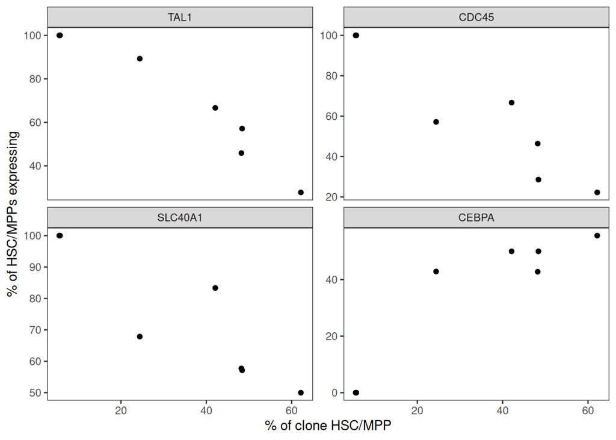

```r
Idents(epiclones_SDR) <- epiclones_SDR$EPIclone_id
epiclones_SDR$EPIclone_id[epiclones_SDR$EPIclone_id == "1"] <- NA

pct.hsc <- sapply(as.character(2:8), function(clone) {
  mean(epiclones_SDR$projected.cluster[Idents(epiclones_SDR) == clone] == "HSC.MPP")
})

fortest <- subset(epiclones_SDR, projected.cluster == "HSC.MPP")

RNA.counts <- GetAssayData(fortest, assay = "RNA", slot = "counts")
rna.ids <- Idents(fortest)[colnames(RNA.counts)]

forplot <- data.frame(
  cluster = as.character(1:8),
  pct.hsc = sapply(as.character(1:8), function(clone) {
    mean(epiclones_SDR$projected.cluster[Idents(epiclones_SDR) == clone] == "HSC.MPP")
  }),
  is.expanded = as.character(1:8) != "1", # assume clone "1" is non-expanded
  t(sapply(as.character(1:8), function(clone) {
    apply(RNA.counts[, rna.ids == clone, drop = FALSE], 1, function(x) mean(x > 0))
  }))
)

forplot <- melt(forplot, id.vars = c("cluster", "is.expanded", "pct.hsc"))

qplot(
  x = 100 * pct.hsc, y = 100 * value,
  data = subset(forplot, is.expanded & variable %in% c("CDC45", "TAL1", "SLC40A1", "CEBPA"))
) +
  theme_bw() +
  theme(panel.grid = element_blank()) +
  facet_wrap(~ factor(variable, levels = c("TAL1", "CDC45", "SLC40A1", "CEBPA")), scales = "free_y") +
  xlab("% of clone HSC/MPP") +
  ylab("% of HSC/MPPs expressing")
```

## Comparison to Mitochondrial linneage tracing (5F,G)

There is ongoing debate over the use of low-heteroplasmy mtDNA variants for lineage tracing. To address this, we analyzed peripheral blood from a 38-year-old donor (X.2) previously profiled by mt-scATAC-seq, and we integrated a mitochondrial targeting panel into scTAM-seq to generate detailed mtDNA profiles alongside EPI-Clone data. This approach enables a direct comparison of phylogenetic relationships between mtDNA variants and EPI-Clones, providing an independent validation of the EPI-Clone method.

```r
load(url("https://figshare.com/ndownloader/files/51355100"))
mito_variants <- read_csv("../Figure5/mito_variants.csv")

mt.ratios <- all_cells@meta.data[, grepl("ratio", colnames(all_cells@meta.data))]
mt.counts <- all_cells@meta.data[, grepl("totalcounts", colnames(all_cells@meta.data))]

use <- mito_variants$position[mito_variants$of_interest == TRUE]
position <- as.integer(gsub("\\D", "", colnames(mt.counts)))
mt.ratios <- mt.ratios[, paste0("chrM:", use, ".ratio")]
mt.counts <- mt.counts[, paste0("chrM:", use, ".totalcounts")]
labels <- mito_variants$label
names(labels) <- mito_variants$position

plf <- melt(
  data.frame(
    CHOIR = all_cells$CHOIR_clusters_0.05,
    ct = all_cells$celltype,
    mt.ratios
  ),
  id.vars = c("CHOIR", "ct")
)
plf$ct <- as.factor(plf$ct)
plf$position <- as.integer(gsub("\\D", "", plf$variable))
plf$label <- unname(labels[as.character(plf$position)])

rate <- ddply(subset(plf, position %in% use),
  c("variable", "position"),
  summarise,
  r = mean(value > 0.05, na.rm = TRUE)
)
v2r <- rate$r
names(v2r) <- rate$variable

# Summarize mutation percentage and other statistics by CHOIR cluster and variant
perc.by.cluster <- ddply(subset(plf, position %in% use),
  c("CHOIR", "variable", "position", "label"),
  summarise,
  perc.mut = mean(value > 0.05, na.rm = TRUE),
  dominant.ct = levels(ct)[which.max(table(ct))],
  perc.dominant = mean(ct == dominant.ct),
  n = sum(!is.na(value)),
  p = pbinom(sum(value > 0.05, na.rm = TRUE),
    prob = v2r[unique(as.character(variable))],
    size = n
  ),
  p.twosided = min(c(p * 2, (1 - p) * 2)),
  class = ifelse(perc.mut > 0.05, "mutant", "wildtype")
)
```

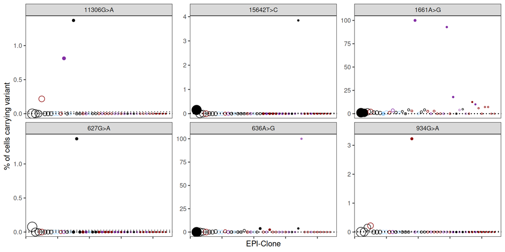

```r
ggplot(
  aes(
    x = CHOIR,
    y = 100 * perc.mut,
    size = n,
    color = ifelse(perc.dominant > 0.8, dominant.ct, "mixed"),
    shape = p.adjust(p.twosided, method = "fdr") < 0.1
  ),
  data = subset(perc.by.cluster, CHOIR != "1" & position != 7077)
) +
  geom_point() +
  scale_color_manual(values = ctcolors, name = "Dominant cell type") +
  theme_bw() +
  theme(
    legend.position = "none",
    panel.grid = element_blank(),
    axis.text.x = element_blank()
  ) +
  geom_hline(aes(yintercept = r),
    linetype = 3,
    data = subset(rate, position != 7077)
  ) +
  scale_size_area(name = "# cells", breaks = c(20, 75, 150)) +
  xlab("EPI-Clone") +
  ylab("% of cells carrying variant") +
  facet_wrap(~label, scales = "free_y", nrow = 2) +
  scale_shape_manual(
    values = c("TRUE" = 19, "FALSE" = 1),
    name = "Enrichment",
    labels = c("TRUE" = "p < 0.05", "FALSE" = "n.s."),
    breaks = c("TRUE", "FALSE")
  )
```

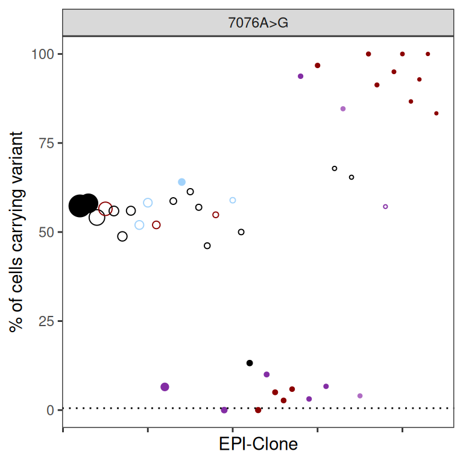

```r
ggplot(
  aes(
    x = CHOIR,
    y = 100 * perc.mut,
    size = n,
    color = ifelse(perc.dominant > 0.8, dominant.ct, "mixed"),
    shape = p.adjust(p.twosided, method = "fdr") < 0.1
  ),
  data = subset(perc.by.cluster, CHOIR != "1" & position == 7077)
) +
  geom_point() +
  scale_color_manual(values = ctcolors, name = "Dominant cell type") +
  theme_bw() +
  theme(
    legend.position = "none",
    panel.grid = element_blank(),
    axis.text.x = element_blank()
  ) +
  geom_hline(aes(yintercept = r),
    linetype = 3,
    data = subset(rate, position == 7077)
  ) +
  scale_size_area(name = "# cells", breaks = c(20, 75, 150)) +
  xlab("EPI-Clone") +
  ylab("% of cells carrying variant") +
  facet_wrap(~label, scales = "free_y", nrow = 2) +
  scale_shape_manual(
    values = c("TRUE" = 19, "FALSE" = 1),
    name = "Enrichment",
    labels = c("TRUE" = "p < 0.05", "FALSE" = "n.s."),
    breaks = c("TRUE", "FALSE")
  )
```